Estimating Discrimination in Sentencing:  
Distinguishing between Good and Bad Controls

Jose Pina-Sánchez

# Can we estimate sentencing discrimination?

## You did not control for […]

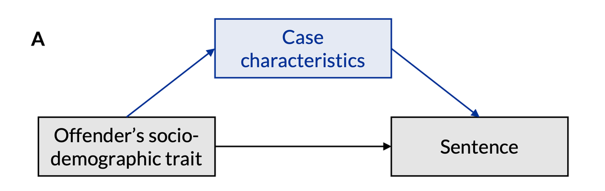

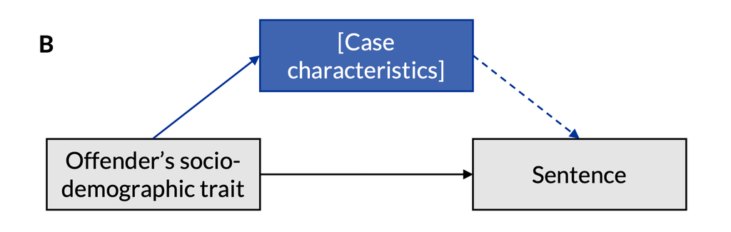

- If you believe on the principle of individualisation, the list of controls is infinite

## Missing legal factors can be ok

- Diminishing returns of explainability for every additional factor
- Confounding bias requires association with the focal variable
- Sometimes the observed disparities are just too big

# What if we were ‘overcontrolling’?

## A more realistic representation

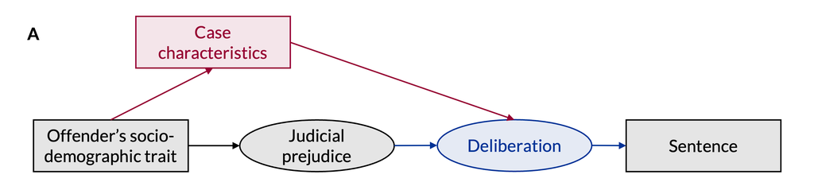

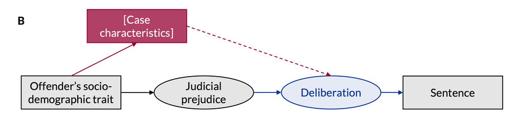

- Target estimand: the effect of judicial prejudice on sentencing
- Proxy estimand: the effect of offender’s socio-demographic trait on sentencing, not mediated through warranted differences

## Judicially-defined case characteristics

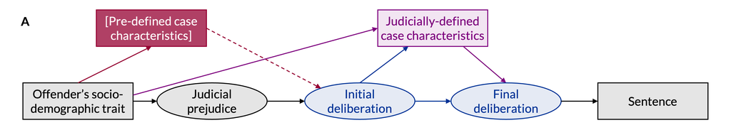

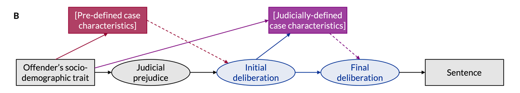

- Pick your poison

## Other offender characteristics

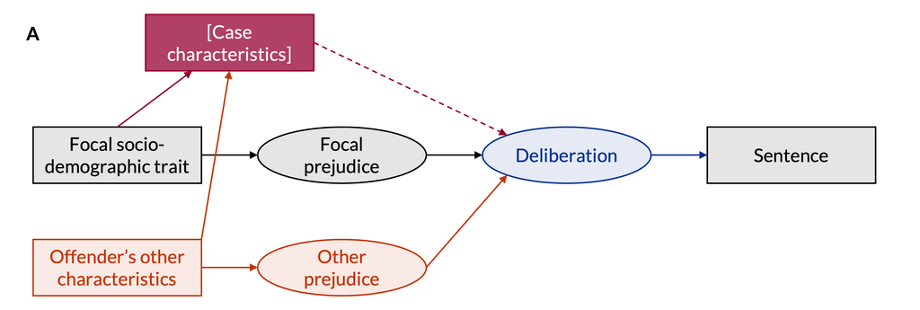

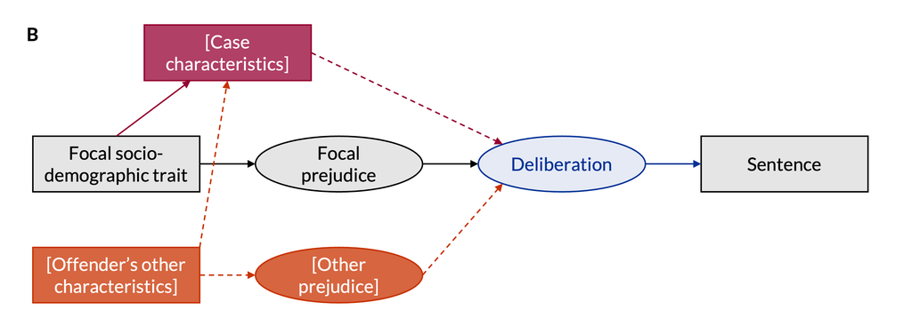

- Estimating discrimination requires accuracy

## Judge characteristics

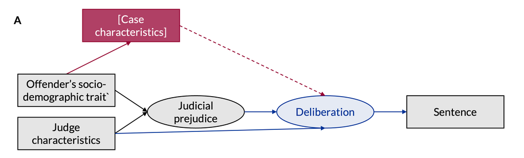

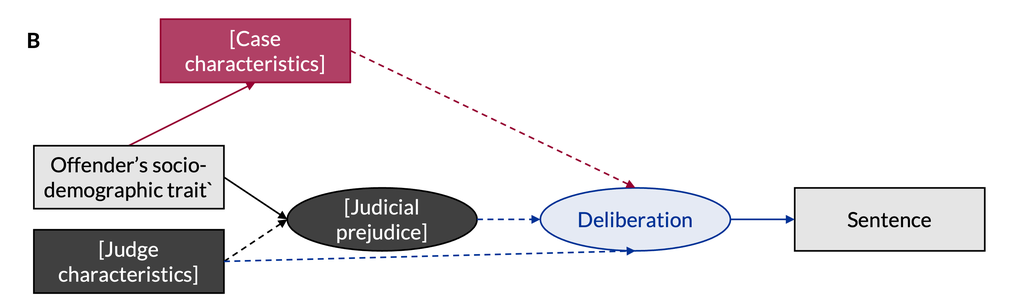

- Useful to explore the origin of disparities, but that is a different question

## Court/area characteristics

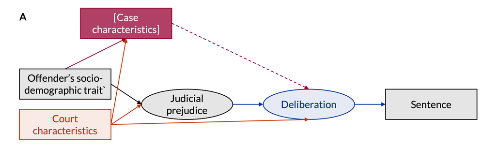

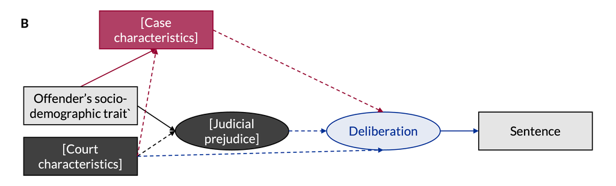

- Another set of endogenous factors

# A new modelling framework

## Step-1: Define the target estimand

- State the specific effect you seek to estimate

  – if interested in direct discrimination then say so
- Clearly state the population of interest

  – decision-makers and decision stages under analysis

## Step-2: Operationalise sentence severity

- Do you consider adjudication?
- Do you consider non-custodial sentences?
- Is sentencing a one- or two-stage process?

## Step-3: List and classify the necessary controls

- Identify all the relevant legal factors
- Classify them as judicially-defined or not
- Identify non-legal factors influencing sentence severity
- Note which ones are missing

## Step-4: Estimate model uncertainty

- Regarding endogenous factors

  – compare models with and without them
- Regarding unobserved legal/non-legal factors

  – E-value (VanderWeele & Ding, 2017)

  – Robustness value (Cinelli & Hazlett, 2020)

## US federal courts: controls

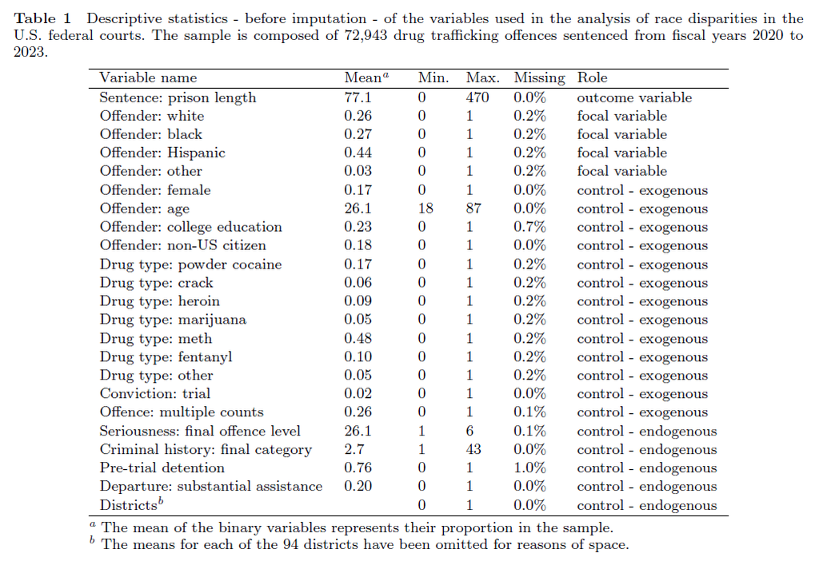

## US federal courts: findings

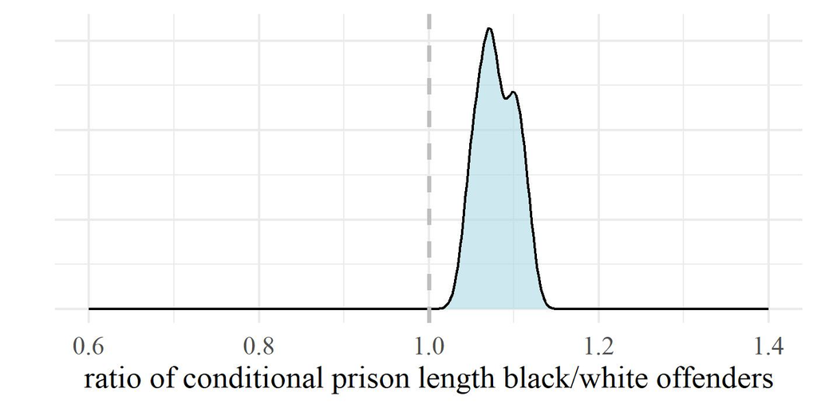

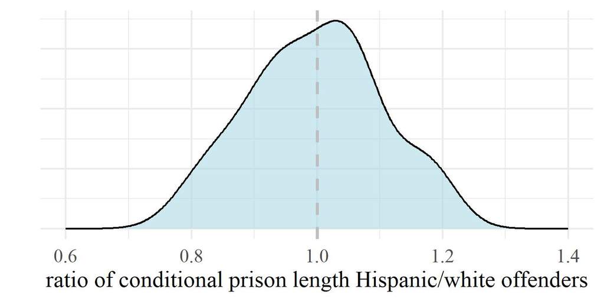

## Conclusion

- The precise level of discrimination in sentencing is unkowable
- Yet, in certain contexts, we can establish its presence/absence
- We need to embrace uncertainty
- The best way to fight scientific nihilism

## Next Steps

- Open research

  – reduce researchers’ degrees of freedom through pre-registrations

  – eliminate publication bias through registered reports
- Sensitivity analysis for unobserved mediators

  – combine different types of model uncertainty
- A comprehensive framework for the estimation of discrimination

  – beyond sentencing, applicable to any decision-making process